# Background and Context

### Mean of residuals should be 0.

```python
residual = olsres3.resid #mean of residuals
np.mean(residual)
```

```
1.9748264764032868e-11
```

Observation:

1. Mean of residuals is close to 0.

### Test for linearity

```python
residual = olsres3.resid
fitted = olsres3.fittedvalues
```

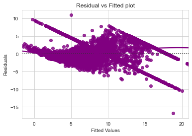

```python
sns.set_style("whitegrid") #residuals vs fitted plot
sns.residplot(fitted, residual, color="purple", lowess=True)
plt.xlabel("Fitted Values")
plt.ylabel("Residuals")
plt.title("Residual vs Fitted plot")
plt.show()
```

Observations:

### Test for Normality

It can be checked via QQ Plot, Residuals following normal distribution will make a straight line plot otherwise not.

Other test to check for normality : Shapiro-Wilk test.

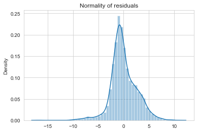

```python
sns.distplot(residual) #desnisty plot
plt.title("Normality of residuals")
plt.show()
```

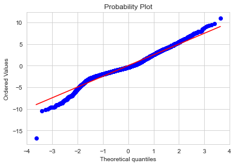

```python
import pylab
import scipy.stats as stats

stats.probplot(residual, dist="norm", plot=pylab)# probabilty plot
plt.show()
```

```python
stats.shapiro(residual) #shapiro test
```

```
ShapiroResult(statistic=0.9686605334281921, pvalue=6.801046498356176e-32)
```

- The residuals are not normal as per shapiro test, but as per QQ plot they are approximately normal.
- The issue with shapiro test is when dataset is big, even for small deviations, it shows data as not normal.
- Hence we go with the QQ plot and say that residuals are normal.
- We can try to treat data for outliers and see if that helps in further normalizing the residual curve.

### TEST FOR HOMOSCEDASTICITY

For goldfeldquandt test, the null and alternate hypotheses are as follows:

Null hypothesis : Residuals are homoscedastic Alternate hypothesis : Residuals have heteroscedasticity

```python
import statsmodels.stats.api as sms
from statsmodels.compat import lzip

name = ["F statistic", "p-value"]
test = sms.het_goldfeldquandt(residual, X_train4)
lzip(name, test)
```

```
[('F statistic', 1.0625766900919138), ('p-value', 0.06509422887655633)]
```

Since p-value > 0.05, we can say that the residuals are homoscedastic. This assumption is therefore valid in the data.

Now we have checked all the assumptions and they are satisfied, so we can move towards the prediction part.

### Predicting on the test data

```python
X_train4.columns
X_train4.shape
```

```
(5075, 54)
```

```python
# Selecting columns from test data that we used to create our final model
X_test_final = X_test[X_train4.columns]
X_test_final.head()
```

|  | const | Unnamed: 0 | Age_of_Car | Kilometers_Driven | Mileage | Power | Name_Audi | Name_BMW | Name_Bentley | Name_Chevrolet | ... | Location_Kolkata | Location_Mumbai | Location_Pune | Fuel_Type_Electric | Fuel_Type_LPG | Fuel_Type_Petrol | Transmission_Manual | Owner_Type_Fourth & Above | Owner_Type_Second | Owner_Type_Third |
| --- | --- | --- | --- | --- | --- | --- | --- | --- | --- | --- | --- | --- | --- | --- | --- | --- | --- | --- | --- | --- | --- |
| 2952 | 1.0 | 2952 | 8.0 | 40000 | 20.77 | 88.80 | 0 | 0 | 0 | 0 | ... | 0 | 0 | 0 | 0 | 0 | 0 | 1 | 0 | 0 | 0 |
| 1634 | 1.0 | 1634 | 4.0 | 68193 | 17.11 | 174.33 | 1 | 0 | 0 | 0 | ... | 0 | 0 | 0 | 0 | 0 | 0 | 0 | 0 | 0 | 0 |
| 2622 | 1.0 | 2622 | 8.0 | 60000 | 19.40 | 86.80 | 0 | 0 | 0 | 0 | ... | 0 | 0 | 0 | 0 | 0 | 1 | 1 | 0 | 0 | 0 |
| 7048 | 1.0 | 7048 | 3.0 | 41200 | 28.09 | 88.50 | 0 | 0 | 0 | 0 | ... | 0 | 0 | 0 | 0 | 0 | 0 | 1 | 0 | 0 | 0 |
| 6732 | 1.0 | 6732 | 3.0 | 35000 | 24.30 | 88.50 | 0 | 0 | 0 | 0 | ... | 0 | 0 | 1 | 0 | 0 | 0 | 1 | 0 | 0 | 0 |

5 rows × 54 columns

```python
# Checking model performance on train set (seen 70% data)
print("Train Performance\n")
print(y_train)
model_perf(olsres3, X_train4.values, y_train)
```

```
Train Performance

          Price
952    3.650000
2264   3.500000
1504   3.000000
7210   9.479468
5538   2.500000
...         ...
3772   4.150000
5191   5.900000
5226  12.500000
5390   2.250000
860    4.750000

[5075 rows x 1 columns]
```

|  | MAE | MAPE | RMSE | R^2 |
| --- | --- | --- | --- | --- |
| 0 | 1.888012 | 32.127677 | 2.523985 | 0.735674 |

```python
# Checking model performance on test set (seen 70% data)
print("Test Performance\n")
model_perf(olsres3, X_test_final.values, y_test)
```

```
Test Performance
```

|  | MAE | MAPE | RMSE | R^2 |
| --- | --- | --- | --- | --- |
| 0 | 1.905936 | 32.76904 | 2.521289 | 0.739767 |

Observation:

1. Now we can see that the model has low test and train RMSE and MAE, and both the errors are comparable. So, our model is not suffering from overfitting.
2. The model is able to explain 73.9% of the variation on the test set, which is very good.
3. The MAPE on the test set suggests we can predict within 32% of the price model.

```python
# let us print the model summary

olsmod3 = sm.OLS(y_train, X_train4)
olsres3 = olsmod3.fit()
print(olsres3.summary())
```

```
                            OLS Regression Results
==============================================================================
Dep. Variable:                  Price   R-squared:                       0.736
Model:                            OLS   Adj. R-squared:                  0.733
Method:                 Least Squares   F-statistic:                     268.8
Date:                Fri, 21 May 2021   Prob (F-statistic):               0.00
Time:                        14:15:03   Log-Likelihood:                -11900.
No. Observations:                5075   AIC:                         2.391e+04
Df Residuals:                    5022   BIC:                         2.425e+04
Df Model:                          52
Covariance Type:            nonrobust
=============================================================================================
                                coef    std err          t      P>|t|      [0.025      0.975]
---------------------------------------------------------------------------------------------
const                        10.0394      0.508     19.780      0.000       9.044      11.034
Unnamed: 0                    0.0003   1.72e-05     14.802      0.000       0.000       0.000
Age_of_Car                   -0.4638      0.016    -28.411      0.000      -0.496      -0.432
Kilometers_Driven          -9.27e-06   1.64e-06     -5.643      0.000   -1.25e-05   -6.05e-06
Mileage                      -0.1359      0.014     -9.689      0.000      -0.163      -0.108
Power                         0.0357      0.002     21.291      0.000       0.032       0.039
Name_Audi                     3.7672      0.258     14.602      0.000       3.261       4.273
Name_BMW                      3.4258      0.264     12.958      0.000       2.907       3.944
Name_Bentley                  3.0443      1.816      1.676      0.094      -0.516       6.605
Name_Chevrolet               -0.8754      0.266     -3.295      0.001      -1.396      -0.354
Name_Datsun                  -1.6471      0.740     -2.226      0.026      -3.098      -0.196
Name_Fiat                    -0.5177      0.498     -1.040      0.298      -1.494       0.458
Name_Force                   -0.0162      1.474     -0.011      0.991      -2.907       2.874
Name_Ford                    -0.4599      0.191     -2.413      0.016      -0.834      -0.086
Name_Hindustan             3.839e-14   1.48e-14      2.599      0.009    9.43e-15    6.74e-14
Name_Honda                   -0.3423      0.146     -2.350      0.019      -0.628      -0.057
Name_Hyundai                 -0.2633      0.121     -2.183      0.029      -0.500      -0.027
Name_ISUZU                   -3.0777      1.809     -1.701      0.089      -6.625       0.469
Name_Isuzu                    1.1564      1.806      0.640      0.522      -2.384       4.697
Name_Jaguar                   3.5052      0.493      7.112      0.000       2.539       4.471
Name_Jeep                     2.9846      0.679      4.397      0.000       1.654       4.315
Name_Lamborghini              6.2018      2.568      2.415      0.016       1.167      11.236
Name_Land                     4.8332      0.423     11.436      0.000       4.005       5.662
Name_Mahindra                -0.4637      0.214     -2.165      0.030      -0.884      -0.044
Name_Mercedes-Benz            3.2235      0.241     13.394      0.000       2.752       3.695
Name_Mini                     6.7308      0.552     12.198      0.000       5.649       7.813
```

[output cut: 24 more lines]

```
Transmission_Manual          -0.7681      0.121     -6.345      0.000      -1.005      -0.531
Owner_Type_Fourth & Above     0.0654      0.854      0.077      0.939      -1.609       1.739
Owner_Type_Second            -0.2550      0.105     -2.429      0.015      -0.461      -0.049
Owner_Type_Third             -0.4825      0.280     -1.720      0.085      -1.032       0.067
==============================================================================
Omnibus:                      198.115   Durbin-Watson:                   2.012
Prob(Omnibus):                  0.000   Jarque-Bera (JB):              612.123
Skew:                           0.029   Prob(JB):                    1.20e-133
Kurtosis:                       4.700   Cond. No.                     1.14e+16
==============================================================================

Notes:
[1] Standard Errors assume that the covariance matrix of the errors is correctly specified.
[2] The smallest eigenvalue is 1.6e-19. This might indicate that there are
strong multicollinearity problems or that the design matrix is singular.
```

# Conclusion

olsres3 is our final model which follows all the assumptions, and can be used for interpretations.

## Recommendation

1. Age of car, mileage and and kilometers driven have all negative impact on the price of car, i.e as any of these values increases the price of the car will significantly reduce.
2. Name of the car is a big indicator in how price is determined, as high-end luxury cars like Lamborghini and Porsche are much higher priced as compared to low-end budget cars like Maruthi or Honda.
3. Location wise the most priced cars are sold in Coimbatore and Kochi, while the low-end, low-price cars are sold in Kolkata, Mumbai etc.
4. Electric cars are much more expensive than any other fuel types and it will be better to sell electric cars as compared to Petrol or Diesel although both these fuel types heavily determine the price.
5. Owner type is also a big indication of the pricing, selling first-hand cars with no previous owners will yield higher price compared to pre-owned cars.
6. The number of seats did not have much of an impact in deciding the price of the car